# **Topic 11 - ggplot2: Grammar of Graphics**

### Grouped (Dodged) Bar Chart

A grouped bar chart places bars for different subgroups side-by-side within each category, making it easy to compare subgroup values both within and across categories.

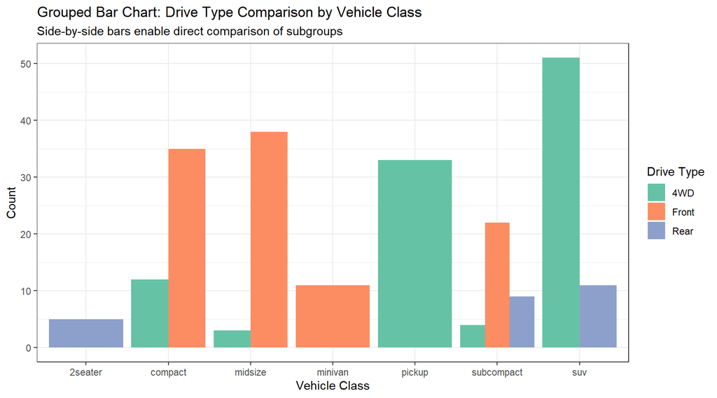

```r
# Grouped bar chart - comparing drive type counts across vehicle classes
ggplot(mpg, aes(x = class, fill = drv)) +
  geom_bar(position = "dodge") +
  scale_fill_manual(values = c("4" = "#66C2A5", "f" = "#FC8D62", "r" = "#8DA0CB"),
                    labels = c("4" = "4WD", "f" = "Front", "r" = "Rear")) +
  labs(
    title = "Grouped Bar Chart: Drive Type Comparison by Vehicle Class",
    subtitle = "Side-by-side bars enable direct comparison of subgroups",
    x = "Vehicle Class",
    y = "Count",
    fill = "Drive Type") +
  theme_bw()
```

**Note:** Grouped bar charts excel at facilitating direct comparisons between subgroups across categories because the side-by-side positioning puts related bars adjacent to each other. They work best when the number of subgroups is small (2-4) to avoid cluttered and unreadable visualizations.

### Filled (Proportional) Bar Chart

A filled bar chart normalizes each bar to the same total height (100%), turning the y-axis into percentages. This emphasizes the relative proportion of subgroups within each category rather than the absolute counts.

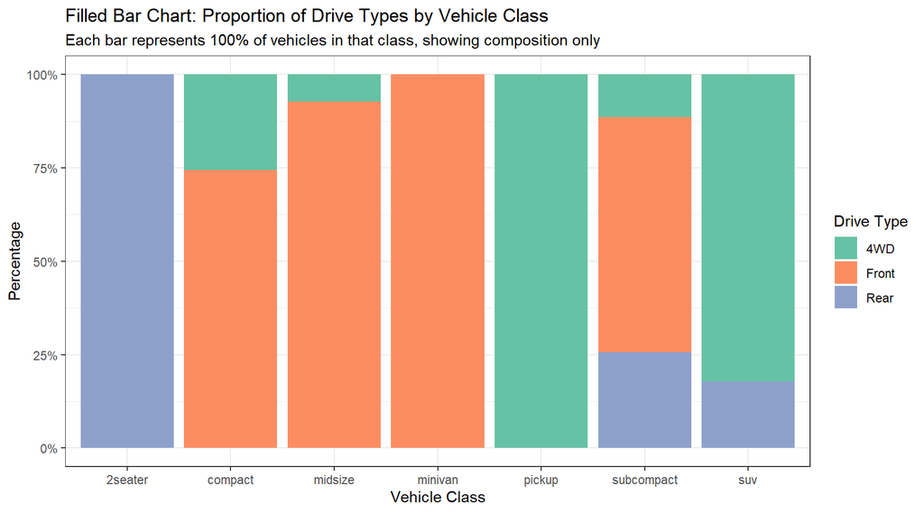

```r
# Filled bar chart - showing proportional composition of drive types within each vehicle class
library(scales)  # For percent formatting

ggplot(mpg, aes(x = class, fill = drv)) +
  geom_bar(position = "fill") +
  scale_y_continuous(labels = percent) +
  scale_fill_manual(values = c("4" = "#66C2A5", "f" = "#FC8D62", "r" = "#8DA0CB"),
                    labels = c("4" = "4WD", "f" = "Front", "r" = "Rear")) +
  labs(
    title = "Filled Bar Chart: Proportion of Drive Types by Vehicle Class",
    subtitle = "Each bar represents 100% of vehicles in that class, showing composition only",
    x = "Vehicle Class",
    y = "Percentage",
    fill = "Drive Type") +
  theme_bw()
```

**Note:** Filled bar charts (using `position = "fill"`) are ideal when comparing proportional composition across categories while ignoring differences in category sizes. They answer questions like **“Which vehicle class has the highest proportion of 4WD vehicles?”** rather than **“Which class has the most 4WD vehicles?”**

## Position Arguments Summary

| Position | Description | Best Used When |
| --- | --- | --- |
| `"stack"` | Bars are stacked on top of each other | Comparing totals and subgroup contributions simultaneously |
| `"dodge"` | Bars are placed side-by-side | Making direct comparisons between subgroup values within and across categories |
| `"fill"` | Bars are normalized to the same height (100%) | Comparing proportional composition across categories regardless of total count differences |
| `"identity"` | Bars overlap (use with transparency) | Visualizing overlapping distributions (less common for bar charts) |

# Key Summaries

## The Grammar of Graphics in a Nutshell

Every **ggplot2** plot follows this template:

```
ggplot(data = DATAFRAME, aes(x = VAR1, y = VAR2)) +
    geom_TYPE() +
  customization_functions()
```

## Choosing the Right Plot Type

| Goal | Plot Type | Geometry Function |
| --- | --- | --- |
| Show relationship between two continuous variables | Scatterplot | `geom_point()` |
| Show trend/relationship | Trend line | `geom_smooth()` |
| Distribution of a continuous variable | Histogram | `geom_histogram()` |
| Distribution of a categorical variable | Bar chart | `geom_bar()` |
| Compare distributions across groups | Boxplot or Violin plot | `geom_boxplot()` or `geom_violin()` |
| Show composition of categories | Stacked/dodged/filled bar chart | `geom_bar(position = ...)` |
| Create multiple small plots | Faceting | `facet_wrap()` or `facet_grid()` |

## Essential ggplot2 Functions

| Function | Purpose | Example with `mpg` |
| --- | --- | --- |
| `ggplot()` | Initialize the plot | `ggplot(mpg, aes(x = displ, y = hwy))` |
| `geom_point()` | Create a scatterplot | `geom_point(color = "blue")` |
| `geom_bar()` | Create a bar chart | `geom_bar(fill = "steelblue")` |
| `geom_histogram()` | Create a histogram | `geom_histogram(bins = 20)` |
| `geom_density()` | Create a density plot | `geom_density(fill = "coral")` |
| `geom_boxplot` | Create a box-plot | `geom_boxplot(y = hwy)` |
| `geom_smooth()` | Add a trend line or line of best fit | `geom_smooth(method = "lm")` |
| `facet_wrap()` | Split into multiple panels by a variable | `facet_wrap(~drv)` |
| `labs()` | Add titles and labels | `labs(title = "My Title")` |
| `theme_*()` | Apply a visual theme | `theme_minimal()` |

## Aesthetic Mapping vs. Setting

| Concept | Syntax | Description | Example |
| --- | --- | --- | --- |
| **Mapping** | Inside `aes()` | Data variable determines visual property | `aes(color = class)` |
| **Setting** | Outside `aes()` | You manually assign a fixed value | `color = "steelblue"` |

### Common Aesthetic Mappings (Inside `aes()`)

| Aesthetic | Maps to… | Example with `mpg` |
| --- | --- | --- |
| `x` | X-axis position | `aes(x = displ)` |
| `y` | Y-axis position | `aes(y = hwy)` |
| `color` | Color of points or outlines | `aes(color = class)` |
| `fill` | Interior color of shapes (bars, boxes) | `aes(fill = drv)` |
| `size` | Size of points or lines | `aes(size = cyl)` |
| `shape` | The visual symbol/shape of a point | `aes(shape = year)` |
| `alpha` | Transparency level based on data values | `aes(alpha = cty)` |

## Position Adjustments for Bar Charts

| Position | Code | What It Does |
| --- | --- | --- |
| Stack | `position = "stack"` (default) | Bars stacked on top of each other |
| Dodge | `position = "dodge"` | Bars placed side-by-side |
| Fill | `position = "fill"` | Bars normalized to 100% height |

## Key Parameters Reference

**For `geom_point()`:** `color`, `size`, `alpha`, `shape`

**For `geom_bar()` / `geom_histogram()`:** `fill` (interior color), `color` (border color), `width`/`binwidth`

**For `geom_boxplot()`:** `fill`, `color`, `outlier.color`, `outlier.size`, `notch`

**For Faceting:**

- `facet_wrap(~variable, ncol = X)`
- `facet_grid(row_variable ~ col_variable)`
- `scales = "free"`, `"free_x"`, `"free_y"`

**For Labels:** `labs(title = "...", subtitle = "...", x = "...", y = "...", caption = "...")`

**For Themes:** `theme_bw()`, `theme_minimal()`, `theme_classic()`, `theme_light()`, `theme_dark()`

## Common Mistakes to Avoid

1. **Forgetting `aes()`:** Mapping variables requires `aes()`, setting fixed aesthetics does not
2. **Using `=` instead of `==` in `aes()`:** Use `==` for conditions outside `aes()` only
3. **Putting `+` at the beginning of a line:** The `+` must end the previous line
4. **Not specifying `stat = "identity"`:** When using pre-summarized data with `geom_bar()`
5. **Confusing `color` and `fill`:** `color` is for outlines/borders, `fill` is for interior